# Modeling Definitions

Definitions of modeling provided **before** the workshop by the PREP 2012 participants.

- Modeling is the distillation of a complex phenomenon into **fundamental** and **quantifiable** pieces that allow us to make predictions.
- Modeling is the best attempt to explain a process.
- Representing or characterizing reality for some predictive purpose.
- Modeling is physical phenomena (including chemistry, biology, etc.) expressed and analyzed through mathematics.
- Using mathematics to combine what we have observed with what we are interested in finding out to give us information about how the world works.
- Collecting, interpreting, and presenting data in a visual, concrete form using patterns (equations) that repeat in many instances.
- Applying mathematics to solve an interesting or practical problem.
- Identifying (or guessing) key factors in a real-world situation and coming up with a systematic way to make predictions based on those.
- Using mathematics to describe phenomena (a situation) and to make predictions.
- Using real-life problems to teach/demonstrate/conceptualize topics and ideas in calculus and mathematics. Bringing the real-world into the classroom.
- Modeling is the process of finding a good mathematical explanation or representation for some observed phenomenon.
- Modeling is the process of constructing, testing, and applying mathematical descriptions to physical and conceptual systems, with the intent of description and/or prediction.
- All models are wrong, but some are useful. How do we teach students to think in terms of models?
- Modeling is using mathematics to match the past and predict the future.
- Modeling is a mathematical framework for predicting outcomes of real-world problems.
- Modeling is using mathematical theory to interpret phenomena of science and engineering.
- Modeling is converting a real-world problem into a math problem.
- Modeling is the process of creating a mathematical construct to solve a real-world problem.
- Modeling is representing reality in a simple enough way to learn something useful.

### A Modeling Definition WordCloud

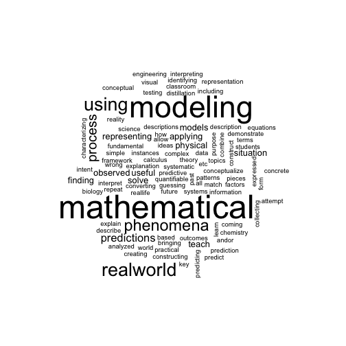

### At the end of the workshop

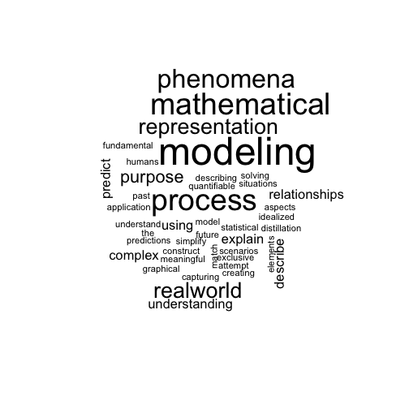

### Calculus Definitions

- Calculus = approximation and limits to get accurate answers.
- Modeling using small amounts of change.
- Calculus – the study of change and the summation of infinite quantities and their application.
- Calculus is the study of how fast changing quantities change and/or accumulate.
- Calculus is the study of change.
- Calculus: study of change.